# Gathering

For this project, I will gather data from three different sources.

## The first source

The `twitter-archive-enhanced.csv` which was provided by *Udacity*.

This file contains the twitter archive of the [WeRateDogs twitter account](https://twitter.com/dog_rates?ref_src=twsrc%5Egoogle%7Ctwcamp%5Eserp%7Ctwgr%5Eauthor) which is

> Your Only Source For Professional Dog Ratings

I downloaded this file manually and added it to the folder of the project under its original name.

##### Storing downloaded data into a pandas DataFrame

```python
import pandas as pd

archive_tweet_df = pd.read_csv("Data/twitter-archive-enhanced.csv")
```

## The second source

The `image_predictions.tsv` which is hosted on *Udacity* servers. This file contains the tweet image predictions, i.e., what breed of dog (or other object, animal, etc.) is present in each tweet according to a neural network.

##### Downloading the file programmatically using *requests* Python module.

```python
import requests

url = "https://d17h27t6h515a5.cloudfront.net/topher/2017/August/599fd2ad_image-predictions/image-predictions.tsv"
predictions_file_path = f"Data/{url.rsplit('/')[-1]}"

response = requests.get(url)

with open(predictions_file_path, "wb") as saved_file:
    saved_file.write(response.content)
```

##### Storing the collected data in a pandas DataFrame

```python
img_pred_df = pd.read_csv(predictions_file_path, sep="\t")
```

## The third source

Using the `tweet_id` column in the WeRateDogs Twitter archive `twitter-archive-enhanced.csv`, I will query the Twitter API for each tweet's JSON data using Python's *Tweepy* module and store each tweet's entire set of JSON data in a file called tweet_json.txt file. Each tweet's JSON data will be written to its own line.

##### Loading secret API keys from environment

```python
import os
from dotenv import load_dotenv

load_dotenv();

CONSUMER_KEY = os.getenv("CONSUMER_KEY")
CONSUMER_SECRET = os.getenv("CONSUMER_SECRET")
ACCESS_TOKEN = os.getenv("ACCESS_TOKEN")
ACCESS_SECRET = os.getenv("ACCESS_SECRET")
```

##### Querying the Twitter API through Tweepy to collect tweets' data

```python
%%time
import tweepy
import json

# Authentication
auth = tweepy.OAuthHandler(CONSUMER_KEY, CONSUMER_SECRET)
auth.set_access_token(ACCESS_TOKEN, ACCESS_SECRET)

api = tweepy.API(auth, wait_on_rate_limit=True, wait_on_rate_limit_notify=True)

tweet_ids = pd.read_csv("Data/twitter-archive-enhanced.csv").tweet_id

with open("Data/tweet-json.txt", "w") as txt_file:
    # For every tweet ID
    for tweet_id in tweet_ids:
        # Try to get the tweet information
        try:
            tweet = api.get_status(tweet_id, tweet_mode="extended")
        except tweepy.TweepError:
            continue

        # If successful, write the json string to the tweet-json.txt file and append a new line
        tweet_json_string = json.dumps(tweet._json)
        txt_file.write(f"{tweet_json_string}\n")
```

```
Rate limit reached. Sleeping for: 257
Rate limit reached. Sleeping for: 298
```

```
CPU times: user 1min 18s, sys: 2.52 s, total: 1min 21s
Wall time: 36min 10s
```

##### Saving collected tweets data into a pandas DataFrame

```python
with open("Data/tweet-json.txt", "r") as txt_file:
    current_tweet_df = pd.read_json(txt_file, lines=True)
```

## Gathering Wrap-up

In this section, I gathered data from 3 different sources.

- `twitter-archive-enhanced.csv` which is now loaded into **`archive_tweet_df`**
- Downloaded `image_predictions.tsv` programmatically from Udacity's servers and loaded into **`img_pred_df`**
- Queried the Twitter API through Tweepy Python module and loaded the data into **`current_tweet_df`**

Random samples of the rows from the three tables are shown below

```python
archive_tweet_df.sample(2)
```

|  | tweet_id | in_reply_to_status_id | in_reply_to_user_id | timestamp | source | text | retweeted_status_id | retweeted_status_user_id | retweeted_status_timestamp | expanded_urls | rating_numerator | rating_denominator | name | doggo | floofer | pupper | puppo |
| --- | --- | --- | --- | --- | --- | --- | --- | --- | --- | --- | --- | --- | --- | --- | --- | --- | --- |
| 595 | 798701998996647937 | NaN | NaN | 2016-11-16 01:39:30 +0000 | <a href="http://twitter.com/download/iphone" r... | RT @dog_rates: We normally don't rate marshmal... | 7.186315e+17 | 4.196984e+09 | 2016-04-09 02:47:55 +0000 | https://twitter.com/dog_rates/status/718631497... | 10 | 10 | None | None | None | None | None |
| 834 | 768473857036525572 | NaN | NaN | 2016-08-24 15:43:39 +0000 | <a href="http://twitter.com/download/iphone" r... | Meet Chevy. He had a late breakfast and now ha... | NaN | NaN | NaN | https://twitter.com/dog_rates/status/768473857... | 11 | 10 | Chevy | None | None | None | None |

```python
img_pred_df.sample(2)
```

|  | tweet_id | jpg_url | img_num | p1 | p1_conf | p1_dog | p2 | p2_conf | p2_dog | p3 | p3_conf | p3_dog |
| --- | --- | --- | --- | --- | --- | --- | --- | --- | --- | --- | --- | --- |
| 292 | 671186162933985280 | https://pbs.twimg.com/media/CVCIQX7UkAEzqh_.jpg | 1 | Chihuahua | 0.319106 | True | whippet | 0.169134 | True | toy_terrier | 0.125815 | True |
| 85 | 667509364010450944 | https://pbs.twimg.com/media/CUN4Or5UAAAa5K4.jpg | 1 | beagle | 0.636169 | True | Labrador_retriever | 0.119256 | True | golden_retriever | 0.082549 | True |

```python
current_tweet_df.sample(2)
```

|  | created_at | id | id_str | full_text | truncated | display_text_range | entities | extended_entities | source | in_reply_to_status_id | ... | favorited | retweeted | possibly_sensitive | possibly_sensitive_appealable | lang | retweeted_status | quoted_status_id | quoted_status_id_str | quoted_status_permalink | quoted_status |
| --- | --- | --- | --- | --- | --- | --- | --- | --- | --- | --- | --- | --- | --- | --- | --- | --- | --- | --- | --- | --- | --- |
| 1180 | 2016-04-01 00:26:15+00:00 | 715696743237730304 | 715696743237730304 | Meet Toby. He's a Lithuanian High-Steppin Stic... | False | [0, 139] | {'hashtags': [], 'symbols': [], 'user_mentions... | {'media': [{'id': 715696738036744192, 'id_str'... | <a href="http://twitter.com/download/iphone" r... | NaN | ... | False | False | 0.0 | 0.0 | en | NaN | NaN | NaN | NaN | NaN |
| 849 | 2016-08-04 01:03:17+00:00 | 761004547850530816 | 761004547850530816 | This is Bo and Ty. Bo eats paper and Ty felt l... | False | [0, 69] | {'hashtags': [], 'symbols': [], 'user_mentions... | {'media': [{'id': 761004543874392064, 'id_str'... | <a href="http://twitter.com/download/iphone" r... | NaN | ... | False | False | 0.0 | 0.0 | en | NaN | NaN | NaN | NaN | NaN |

2 rows × 32 columns

# Assessment

## Assessing `archive_tweet_df`

### Visual assessment

```python
archive_tweet_df.head()
```

|  | tweet_id | in_reply_to_status_id | in_reply_to_user_id | timestamp | source | text | retweeted_status_id | retweeted_status_user_id | retweeted_status_timestamp | expanded_urls | rating_numerator | rating_denominator | name | doggo | floofer | pupper | puppo |
| --- | --- | --- | --- | --- | --- | --- | --- | --- | --- | --- | --- | --- | --- | --- | --- | --- | --- |
| 0 | 892420643555336193 | NaN | NaN | 2017-08-01 16:23:56 +0000 | <a href="http://twitter.com/download/iphone" r... | This is Phineas. He's a mystical boy. Only eve... | NaN | NaN | NaN | https://twitter.com/dog_rates/status/892420643... | 13 | 10 | Phineas | None | None | None | None |
| 1 | 892177421306343426 | NaN | NaN | 2017-08-01 00:17:27 +0000 | <a href="http://twitter.com/download/iphone" r... | This is Tilly. She's just checking pup on you.... | NaN | NaN | NaN | https://twitter.com/dog_rates/status/892177421... | 13 | 10 | Tilly | None | None | None | None |
| 2 | 891815181378084864 | NaN | NaN | 2017-07-31 00:18:03 +0000 | <a href="http://twitter.com/download/iphone" r... | This is Archie. He is a rare Norwegian Pouncin... | NaN | NaN | NaN | https://twitter.com/dog_rates/status/891815181... | 12 | 10 | Archie | None | None | None | None |
| 3 | 891689557279858688 | NaN | NaN | 2017-07-30 15:58:51 +0000 | <a href="http://twitter.com/download/iphone" r... | This is Darla. She commenced a snooze mid meal... | NaN | NaN | NaN | https://twitter.com/dog_rates/status/891689557... | 13 | 10 | Darla | None | None | None | None |
| 4 | 891327558926688256 | NaN | NaN | 2017-07-29 16:00:24 +0000 | <a href="http://twitter.com/download/iphone" r... | This is Franklin. He would like you to stop ca... | NaN | NaN | NaN | https://twitter.com/dog_rates/status/891327558... | 12 | 10 | Franklin | None | None | None | None |

```python
archive_tweet_df.tail()
```

|  | tweet_id | in_reply_to_status_id | in_reply_to_user_id | timestamp | source | text | retweeted_status_id | retweeted_status_user_id | retweeted_status_timestamp | expanded_urls | rating_numerator | rating_denominator | name | doggo | floofer | pupper | puppo |
| --- | --- | --- | --- | --- | --- | --- | --- | --- | --- | --- | --- | --- | --- | --- | --- | --- | --- |
| 2351 | 666049248165822465 | NaN | NaN | 2015-11-16 00:24:50 +0000 | <a href="http://twitter.com/download/iphone" r... | Here we have a 1949 1st generation vulpix. Enj... | NaN | NaN | NaN | https://twitter.com/dog_rates/status/666049248... | 5 | 10 | None | None | None | None | None |
| 2352 | 666044226329800704 | NaN | NaN | 2015-11-16 00:04:52 +0000 | <a href="http://twitter.com/download/iphone" r... | This is a purebred Piers Morgan. Loves to Netf... | NaN | NaN | NaN | https://twitter.com/dog_rates/status/666044226... | 6 | 10 | a | None | None | None | None |
| 2353 | 666033412701032449 | NaN | NaN | 2015-11-15 23:21:54 +0000 | <a href="http://twitter.com/download/iphone" r... | Here is a very happy pup. Big fan of well-main... | NaN | NaN | NaN | https://twitter.com/dog_rates/status/666033412... | 9 | 10 | a | None | None | None | None |
| 2354 | 666029285002620928 | NaN | NaN | 2015-11-15 23:05:30 +0000 | <a href="http://twitter.com/download/iphone" r... | This is a western brown Mitsubishi terrier. Up... | NaN | NaN | NaN | https://twitter.com/dog_rates/status/666029285... | 7 | 10 | a | None | None | None | None |
| 2355 | 666020888022790149 | NaN | NaN | 2015-11-15 22:32:08 +0000 | <a href="http://twitter.com/download/iphone" r... | Here we have a Japanese Irish Setter. Lost eye... | NaN | NaN | NaN | https://twitter.com/dog_rates/status/666020888... | 8 | 10 | None | None | None | None | None |

```python
archive_tweet_df.sample(5)
```

|  | tweet_id | in_reply_to_status_id | in_reply_to_user_id | timestamp | source | text | retweeted_status_id | retweeted_status_user_id | retweeted_status_timestamp | expanded_urls | rating_numerator | rating_denominator | name | doggo | floofer | pupper | puppo |
| --- | --- | --- | --- | --- | --- | --- | --- | --- | --- | --- | --- | --- | --- | --- | --- | --- | --- |
| 1816 | 676606785097199616 | NaN | NaN | 2015-12-15 03:36:42 +0000 | <a href="http://twitter.com/download/iphone" r... | *screeches for a sec and then faints* 12/10 ht... | NaN | NaN | NaN | https://twitter.com/dog_rates/status/676606785... | 12 | 10 | None | None | None | None | None |
| 638 | 793271401113350145 | NaN | NaN | 2016-11-01 02:00:14 +0000 | <a href="http://twitter.com/download/iphone" r... | Meet Dave. It's his favorite day of the year. ... | NaN | NaN | NaN | https://twitter.com/dog_rates/status/793271401... | 12 | 10 | Dave | None | None | None | None |
| 538 | 806620845233815552 | NaN | NaN | 2016-12-07 22:06:10 +0000 | <a href="http://twitter.com/download/iphone" r... | RT @dog_rates: Idk why this keeps happening. W... | 7.815247e+17 | 4.196984e+09 | 2016-09-29 16:03:01 +0000 | https://twitter.com/dog_rates/status/781524693... | 12 | 10 | None | None | None | None | None |
| 477 | 815990720817401858 | NaN | NaN | 2017-01-02 18:38:42 +0000 | <a href="http://twitter.com/download/iphone" r... | Meet Jack. He's one of the rare doggos that do... | NaN | NaN | NaN | https://www.gofundme.com/surgeryforjacktheminp... | 11 | 10 | Jack | None | None | None | None |
| 1703 | 680913438424612864 | NaN | NaN | 2015-12-27 00:49:49 +0000 | <a href="http://twitter.com/download/iphone" r... | Meet Griswold. He's dapper as hell. Already pu... | NaN | NaN | NaN | https://twitter.com/dog_rates/status/680913438... | 11 | 10 | Griswold | None | None | None | None |

### Programmatic assessment

```python
archive_tweet_df.info()
```

```
<class 'pandas.core.frame.DataFrame'>
RangeIndex: 2356 entries, 0 to 2355
Data columns (total 17 columns):
 #   Column                      Non-Null Count  Dtype
---  ------                      --------------  -----
 0   tweet_id                    2356 non-null   int64
 1   in_reply_to_status_id       78 non-null     float64
 2   in_reply_to_user_id         78 non-null     float64
 3   timestamp                   2356 non-null   object
 4   source                      2356 non-null   object
 5   text                        2356 non-null   object
 6   retweeted_status_id         181 non-null    float64
 7   retweeted_status_user_id    181 non-null    float64
 8   retweeted_status_timestamp  181 non-null    object
 9   expanded_urls               2297 non-null   object
 10  rating_numerator            2356 non-null   int64
 11  rating_denominator          2356 non-null   int64
 12  name                        2356 non-null   object
 13  doggo                       2356 non-null   object
 14  floofer                     2356 non-null   object
 15  pupper                      2356 non-null   object
 16  puppo                       2356 non-null   object
dtypes: float64(4), int64(3), object(10)
memory usage: 313.0+ KB
```

```python
archive_tweet_df.describe()
```

|  | tweet_id | in_reply_to_status_id | in_reply_to_user_id | retweeted_status_id | retweeted_status_user_id | rating_numerator | rating_denominator |
| --- | --- | --- | --- | --- | --- | --- | --- |
| count | 2.356000e+03 | 7.800000e+01 | 7.800000e+01 | 1.810000e+02 | 1.810000e+02 | 2356.000000 | 2356.000000 |
| mean | 7.427716e+17 | 7.455079e+17 | 2.014171e+16 | 7.720400e+17 | 1.241698e+16 | 13.126486 | 10.455433 |
| std | 6.856705e+16 | 7.582492e+16 | 1.252797e+17 | 6.236928e+16 | 9.599254e+16 | 45.876648 | 6.745237 |
| min | 6.660209e+17 | 6.658147e+17 | 1.185634e+07 | 6.661041e+17 | 7.832140e+05 | 0.000000 | 0.000000 |
| 25% | 6.783989e+17 | 6.757419e+17 | 3.086374e+08 | 7.186315e+17 | 4.196984e+09 | 10.000000 | 10.000000 |
| 50% | 7.196279e+17 | 7.038708e+17 | 4.196984e+09 | 7.804657e+17 | 4.196984e+09 | 11.000000 | 10.000000 |
| 75% | 7.993373e+17 | 8.257804e+17 | 4.196984e+09 | 8.203146e+17 | 4.196984e+09 | 12.000000 | 10.000000 |
| max | 8.924206e+17 | 8.862664e+17 | 8.405479e+17 | 8.874740e+17 | 7.874618e+17 | 1776.000000 | 170.000000 |

```python
archive_tweet_df.rating_denominator.value_counts()
```

```
10     2333
11        3
50        3
80        2
20        2
2         1
16        1
40        1
70        1
15        1
90        1
110       1
120       1
130       1
150       1
170       1
7         1
0         1
Name: rating_denominator, dtype: int64
```

```python
archive_tweet_df.source.unique()
```

```
array(['<a href="http://twitter.com/download/iphone" rel="nofollow">Twitter for iPhone</a>',
       '<a href="http://twitter.com" rel="nofollow">Twitter Web Client</a>',
       '<a href="http://vine.co" rel="nofollow">Vine - Make a Scene</a>',
       '<a href="https://about.twitter.com/products/tweetdeck" rel="nofollow">TweetDeck</a>'],
      dtype=object)
```

`source` looks like an irrelevant variable to my project. An easy decision to make after taking a look at its unique values in the code cell above.

```python
archive_tweet_df.name.value_counts()
```

```
None       745
a           55
Charlie     12
Oliver      11
Lucy        11
          ...
Stark        1
Brandy       1
Sora         1
Maisey       1
Hero         1
Name: name, Length: 957, dtype: int64
```

```python
from pprint import PrettyPrinter

printer = PrettyPrinter(compact=True)


printer.pprint(
    [
        dog_name
        for dog_name in list(archive_tweet_df.name.unique())
        if not dog_name[
            0
        ].isupper()  # The first letter of a valid name should be uppercase
    ]
)
```

```
['such', 'a', 'quite', 'not', 'one', 'incredibly', 'mad', 'an', 'very', 'just',
 'my', 'his', 'actually', 'getting', 'this', 'unacceptable', 'all', 'old',
 'infuriating', 'the', 'by', 'officially', 'life', 'light', 'space']
```

### Findings

##### Quality Issues

- Missing values in `in_reply_to_status_id`, `in_reply_to_user_id`, `retweeted_status_id`,`retweeted_status_user_id`, `retweeted_status_timestamp`, `expanded_urls`
- Irrelevant data in `source` column
- Inconsistent rating system as seen in this code cell
- Erroneous data type for the `timestamp` column
- "None" is used to refer to missing information in `name`, `doggo`, `pupper`, `puppo` and `floofer` columns
- Inaccurately parsed dog names in `name` such as "a", "an", "my" and "by"

##### Tidiness Issues

- Dog age information is distributed over 4 columns (Doggo, Pupper, Floofer, Puppo), this violates the first tidy data requirement "Each variable forms a column".

## Assessing `img_pred_df`

### Visual assessment

```python
img_pred_df.head()
```

|  | tweet_id | jpg_url | img_num | p1 | p1_conf | p1_dog | p2 | p2_conf | p2_dog | p3 | p3_conf | p3_dog |
| --- | --- | --- | --- | --- | --- | --- | --- | --- | --- | --- | --- | --- |
| 0 | 666020888022790149 | https://pbs.twimg.com/media/CT4udn0WwAA0aMy.jpg | 1 | Welsh_springer_spaniel | 0.465074 | True | collie | 0.156665 | True | Shetland_sheepdog | 0.061428 | True |
| 1 | 666029285002620928 | https://pbs.twimg.com/media/CT42GRgUYAA5iDo.jpg | 1 | redbone | 0.506826 | True | miniature_pinscher | 0.074192 | True | Rhodesian_ridgeback | 0.072010 | True |
| 2 | 666033412701032449 | https://pbs.twimg.com/media/CT4521TWwAEvMyu.jpg | 1 | German_shepherd | 0.596461 | True | malinois | 0.138584 | True | bloodhound | 0.116197 | True |
| 3 | 666044226329800704 | https://pbs.twimg.com/media/CT5Dr8HUEAA-lEu.jpg | 1 | Rhodesian_ridgeback | 0.408143 | True | redbone | 0.360687 | True | miniature_pinscher | 0.222752 | True |
| 4 | 666049248165822465 | https://pbs.twimg.com/media/CT5IQmsXIAAKY4A.jpg | 1 | miniature_pinscher | 0.560311 | True | Rottweiler | 0.243682 | True | Doberman | 0.154629 | True |

```python
img_pred_df.tail()
```

|  | tweet_id | jpg_url | img_num | p1 | p1_conf | p1_dog | p2 | p2_conf | p2_dog | p3 | p3_conf | p3_dog |
| --- | --- | --- | --- | --- | --- | --- | --- | --- | --- | --- | --- | --- |
| 2070 | 891327558926688256 | https://pbs.twimg.com/media/DF6hr6BUMAAzZgT.jpg | 2 | basset | 0.555712 | True | English_springer | 0.225770 | True | German_short-haired_pointer | 0.175219 | True |
| 2071 | 891689557279858688 | https://pbs.twimg.com/media/DF_q7IAWsAEuuN8.jpg | 1 | paper_towel | 0.170278 | False | Labrador_retriever | 0.168086 | True | spatula | 0.040836 | False |
| 2072 | 891815181378084864 | https://pbs.twimg.com/media/DGBdLU1WsAANxJ9.jpg | 1 | Chihuahua | 0.716012 | True | malamute | 0.078253 | True | kelpie | 0.031379 | True |
| 2073 | 892177421306343426 | https://pbs.twimg.com/media/DGGmoV4XsAAUL6n.jpg | 1 | Chihuahua | 0.323581 | True | Pekinese | 0.090647 | True | papillon | 0.068957 | True |
| 2074 | 892420643555336193 | https://pbs.twimg.com/media/DGKD1-bXoAAIAUK.jpg | 1 | orange | 0.097049 | False | bagel | 0.085851 | False | banana | 0.076110 | False |

```python
img_pred_df.sample(5)
```

|  | tweet_id | jpg_url | img_num | p1 | p1_conf | p1_dog | p2 | p2_conf | p2_dog | p3 | p3_conf | p3_dog |
| --- | --- | --- | --- | --- | --- | --- | --- | --- | --- | --- | --- | --- |
| 175 | 669037058363662336 | https://pbs.twimg.com/media/CUjlp51WcAA1vGA.jpg | 1 | Chihuahua | 0.803528 | True | Pomeranian | 0.053871 | True | chow | 0.032257 | True |
| 1593 | 798694562394996736 | https://pbs.twimg.com/media/Cbs3DOAXIAAp3Bd.jpg | 1 | Chihuahua | 0.615163 | True | Pembroke | 0.159509 | True | basenji | 0.084466 | True |
| 684 | 683852578183077888 | https://pbs.twimg.com/media/CX2ISqSWYAAEtCF.jpg | 1 | toy_poodle | 0.551352 | True | teddy | 0.180678 | False | miniature_poodle | 0.164095 | True |
| 1938 | 860524505164394496 | https://pbs.twimg.com/media/C_EyeKuXkAAdxY-.jpg | 1 | Bedlington_terrier | 0.286558 | True | toy_poodle | 0.235193 | True | Lakeland_terrier | 0.087951 | True |
| 653 | 682047327939461121 | https://pbs.twimg.com/media/CXcebTeWsAUQJ-J.jpg | 1 | teddy | 0.364095 | False | doormat | 0.119243 | False | toyshop | 0.035127 | False |

### Programmatic assessment

```python
img_pred_df.info()
```

```
<class 'pandas.core.frame.DataFrame'>
RangeIndex: 2075 entries, 0 to 2074
Data columns (total 12 columns):
 #   Column    Non-Null Count  Dtype
---  ------    --------------  -----
 0   tweet_id  2075 non-null   int64
 1   jpg_url   2075 non-null   object
 2   img_num   2075 non-null   int64
 3   p1        2075 non-null   object
 4   p1_conf   2075 non-null   float64
 5   p1_dog    2075 non-null   bool
 6   p2        2075 non-null   object
 7   p2_conf   2075 non-null   float64
 8   p2_dog    2075 non-null   bool
 9   p3        2075 non-null   object
 10  p3_conf   2075 non-null   float64
 11  p3_dog    2075 non-null   bool
dtypes: bool(3), float64(3), int64(2), object(4)
memory usage: 152.1+ KB
```

```python
img_pred_df.describe()
```

|  | tweet_id | img_num | p1_conf | p2_conf | p3_conf |
| --- | --- | --- | --- | --- | --- |
| count | 2.075000e+03 | 2075.000000 | 2075.000000 | 2.075000e+03 | 2.075000e+03 |
| mean | 7.384514e+17 | 1.203855 | 0.594548 | 1.345886e-01 | 6.032417e-02 |
| std | 6.785203e+16 | 0.561875 | 0.271174 | 1.006657e-01 | 5.090593e-02 |
| min | 6.660209e+17 | 1.000000 | 0.044333 | 1.011300e-08 | 1.740170e-10 |
| 25% | 6.764835e+17 | 1.000000 | 0.364412 | 5.388625e-02 | 1.622240e-02 |
| 50% | 7.119988e+17 | 1.000000 | 0.588230 | 1.181810e-01 | 4.944380e-02 |
| 75% | 7.932034e+17 | 1.000000 | 0.843855 | 1.955655e-01 | 9.180755e-02 |
| max | 8.924206e+17 | 4.000000 | 1.000000 | 4.880140e-01 | 2.734190e-01 |

### Findings

This table looks much cleaner which is something I anticipated, it was created by a fellow data analyst after all. However, ther are minor inconveniences which must be mentioned.

##### Quality Issues

- Missing records compared to `archive_tweet_df`, this table has 2075 entries while the former one has 2356 entries.
- Records of images that do not have a dog in them the image prediction algorithm could not identify a dog in them i.e. records that have `p1_dog` = `p2_dog` = `p3_dog` = `False`

##### Tidiness Issues

- We have 6 columns (`p1`, `p1_conf`, `p1_dog`, ...etc.) that should only be represented in one column so we do not violate the first tidy data requirement "each variable forms a column". All 6 columns just provide one piece of information which is the dog breed.

## Assessing `current_tweet_df`

### Visual assessment

```python
current_tweet_df.head()
```

|  | created_at | id | id_str | full_text | truncated | display_text_range | entities | extended_entities | source | in_reply_to_status_id | ... | favorited | retweeted | possibly_sensitive | possibly_sensitive_appealable | lang | retweeted_status | quoted_status_id | quoted_status_id_str | quoted_status_permalink | quoted_status |
| --- | --- | --- | --- | --- | --- | --- | --- | --- | --- | --- | --- | --- | --- | --- | --- | --- | --- | --- | --- | --- | --- |
| 0 | 2017-08-01 16:23:56+00:00 | 892420643555336193 | 892420643555336192 | This is Phineas. He's a mystical boy. Only eve... | False | [0, 85] | {'hashtags': [], 'symbols': [], 'user_mentions... | {'media': [{'id': 892420639486877696, 'id_str'... | <a href="http://twitter.com/download/iphone" r... | NaN | ... | False | False | 0.0 | 0.0 | en | NaN | NaN | NaN | NaN | NaN |
| 1 | 2017-08-01 00:17:27+00:00 | 892177421306343426 | 892177421306343424 | This is Tilly. She's just checking pup on you.... | False | [0, 138] | {'hashtags': [], 'symbols': [], 'user_mentions... | {'media': [{'id': 892177413194625024, 'id_str'... | <a href="http://twitter.com/download/iphone" r... | NaN | ... | False | False | 0.0 | 0.0 | en | NaN | NaN | NaN | NaN | NaN |
| 2 | 2017-07-31 00:18:03+00:00 | 891815181378084864 | 891815181378084864 | This is Archie. He is a rare Norwegian Pouncin... | False | [0, 121] | {'hashtags': [], 'symbols': [], 'user_mentions... | {'media': [{'id': 891815175371796480, 'id_str'... | <a href="http://twitter.com/download/iphone" r... | NaN | ... | False | False | 0.0 | 0.0 | en | NaN | NaN | NaN | NaN | NaN |
| 3 | 2017-07-30 15:58:51+00:00 | 891689557279858688 | 891689557279858688 | This is Darla. She commenced a snooze mid meal... | False | [0, 79] | {'hashtags': [], 'symbols': [], 'user_mentions... | {'media': [{'id': 891689552724799489, 'id_str'... | <a href="http://twitter.com/download/iphone" r... | NaN | ... | False | False | 0.0 | 0.0 | en | NaN | NaN | NaN | NaN | NaN |
| 4 | 2017-07-29 16:00:24+00:00 | 891327558926688256 | 891327558926688256 | This is Franklin. He would like you to stop ca... | False | [0, 138] | {'hashtags': [{'text': 'BarkWeek', 'indices': ... | {'media': [{'id': 891327551943041024, 'id_str'... | <a href="http://twitter.com/download/iphone" r... | NaN | ... | False | False | 0.0 | 0.0 | en | NaN | NaN | NaN | NaN | NaN |

5 rows × 32 columns

```python
current_tweet_df.tail()
```

|  | created_at | id | id_str | full_text | truncated | display_text_range | entities | extended_entities | source | in_reply_to_status_id | ... | favorited | retweeted | possibly_sensitive | possibly_sensitive_appealable | lang | retweeted_status | quoted_status_id | quoted_status_id_str | quoted_status_permalink | quoted_status |
| --- | --- | --- | --- | --- | --- | --- | --- | --- | --- | --- | --- | --- | --- | --- | --- | --- | --- | --- | --- | --- | --- |
| 2316 | 2015-11-16 00:24:50+00:00 | 666049248165822465 | 666049248165822464 | Here we have a 1949 1st generation vulpix. Enj... | False | [0, 120] | {'hashtags': [], 'symbols': [], 'user_mentions... | {'media': [{'id': 666049244999131136, 'id_str'... | <a href="http://twitter.com/download/iphone" r... | NaN | ... | False | False | 0.0 | 0.0 | en | NaN | NaN | NaN | NaN | NaN |
| 2317 | 2015-11-16 00:04:52+00:00 | 666044226329800704 | 666044226329800704 | This is a purebred Piers Morgan. Loves to Netf... | False | [0, 137] | {'hashtags': [], 'symbols': [], 'user_mentions... | {'media': [{'id': 666044217047650304, 'id_str'... | <a href="http://twitter.com/download/iphone" r... | NaN | ... | False | False | 0.0 | 0.0 | en | NaN | NaN | NaN | NaN | NaN |
| 2318 | 2015-11-15 23:21:54+00:00 | 666033412701032449 | 666033412701032448 | Here is a very happy pup. Big fan of well-main... | False | [0, 130] | {'hashtags': [], 'symbols': [], 'user_mentions... | {'media': [{'id': 666033409081393153, 'id_str'... | <a href="http://twitter.com/download/iphone" r... | NaN | ... | False | False | 0.0 | 0.0 | en | NaN | NaN | NaN | NaN | NaN |
| 2319 | 2015-11-15 23:05:30+00:00 | 666029285002620928 | 666029285002620928 | This is a western brown Mitsubishi terrier. Up... | False | [0, 139] | {'hashtags': [], 'symbols': [], 'user_mentions... | {'media': [{'id': 666029276303482880, 'id_str'... | <a href="http://twitter.com/download/iphone" r... | NaN | ... | False | False | 0.0 | 0.0 | en | NaN | NaN | NaN | NaN | NaN |
| 2320 | 2015-11-15 22:32:08+00:00 | 666020888022790149 | 666020888022790144 | Here we have a Japanese Irish Setter. Lost eye... | False | [0, 131] | {'hashtags': [], 'symbols': [], 'user_mentions... | {'media': [{'id': 666020881337073664, 'id_str'... | <a href="http://twitter.com/download/iphone" r... | NaN | ... | False | False | 0.0 | 0.0 | en | NaN | NaN | NaN | NaN | NaN |

5 rows × 32 columns

```python
current_tweet_df.sample(5)
```

|  | created_at | id | id_str | full_text | truncated | display_text_range | entities | extended_entities | source | in_reply_to_status_id | ... | favorited | retweeted | possibly_sensitive | possibly_sensitive_appealable | lang | retweeted_status | quoted_status_id | quoted_status_id_str | quoted_status_permalink | quoted_status |
| --- | --- | --- | --- | --- | --- | --- | --- | --- | --- | --- | --- | --- | --- | --- | --- | --- | --- | --- | --- | --- | --- |
| 67 | 2017-06-26 00:13:58+00:00 | 879130579576475649 | 879130579576475648 | RT @dog_rates: This is Emmy. She was adopted t... | False | [0, 140] | {'hashtags': [], 'symbols': [], 'user_mentions... | NaN | <a href="http://twitter.com/download/iphone" r... | NaN | ... | False | False | NaN | NaN | en | {'created_at': 'Fri Jun 23 01:10:23 +0000 2017... | NaN | NaN | NaN | NaN |
| 196 | 2017-04-12 18:25:07+00:00 | 852226086759018497 | 852226086759018496 | Meet General. He wasn't content with the quali... | False | [0, 137] | {'hashtags': [], 'symbols': [], 'user_mentions... | {'media': [{'id': 852223481894903808, 'id_str'... | <a href="http://twitter.com" rel="nofollow">Tw... | NaN | ... | False | False | 0.0 | 0.0 | en | NaN | NaN | NaN | NaN | NaN |
| 89 | 2017-06-13 17:29:20+00:00 | 874680097055178752 | 874680097055178752 | Meet Cash. He hath acquired a stick. A very go... | False | [0, 92] | {'hashtags': [], 'symbols': [], 'user_mentions... | {'media': [{'id': 874680081829904384, 'id_str'... | <a href="http://twitter.com/download/iphone" r... | NaN | ... | False | False | 0.0 | 0.0 | en | NaN | NaN | NaN | NaN | NaN |
| 1863 | 2015-12-10 00:10:43+00:00 | 674743008475090944 | 674743008475090944 | This is Sophie. She just saw a spider. 10/10 d... | False | [0, 98] | {'hashtags': [], 'symbols': [], 'user_mentions... | {'media': [{'id': 674743003064438784, 'id_str'... | <a href="http://twitter.com/download/iphone" r... | NaN | ... | False | False | 0.0 | 0.0 | en | NaN | NaN | NaN | NaN | NaN |
| 1497 | 2016-01-22 02:28:52+00:00 | 690360449368465409 | 690360449368465408 | Stop sending in lobsters. This is the final wa... | False | [0, 113] | {'hashtags': [], 'symbols': [], 'user_mentions... | {'media': [{'id': 690360446273110016, 'id_str'... | <a href="http://twitter.com/download/iphone" r... | NaN | ... | False | False | 0.0 | 0.0 | en | NaN | NaN | NaN | NaN | NaN |

5 rows × 32 columns

### Programmatic assessment

```python
current_tweet_df.info()
```

```
<class 'pandas.core.frame.DataFrame'>
RangeIndex: 2321 entries, 0 to 2320
Data columns (total 32 columns):
 #   Column                         Non-Null Count  Dtype
---  ------                         --------------  -----
 0   created_at                     2321 non-null   datetime64[ns, UTC]
 1   id                             2321 non-null   int64
 2   id_str                         2321 non-null   int64
 3   full_text                      2321 non-null   object
 4   truncated                      2321 non-null   bool
 5   display_text_range             2321 non-null   object
 6   entities                       2321 non-null   object
 7   extended_entities              2050 non-null   object
 8   source                         2321 non-null   object
 9   in_reply_to_status_id          77 non-null     float64
```

[output cut: 24 more lines]

```python
current_tweet_df.describe()
```

|  | id | id_str | in_reply_to_status_id | in_reply_to_status_id_str | in_reply_to_user_id | in_reply_to_user_id_str | geo | coordinates | contributors | retweet_count | favorite_count | possibly_sensitive | possibly_sensitive_appealable | quoted_status_id | quoted_status_id_str |
| --- | --- | --- | --- | --- | --- | --- | --- | --- | --- | --- | --- | --- | --- | --- | --- |
| count | 2.321000e+03 | 2.321000e+03 | 7.700000e+01 | 7.700000e+01 | 7.700000e+01 | 7.700000e+01 | 0.0 | 0.0 | 0.0 | 2321.000000 | 2321.000000 | 2188.0 | 2188.0 | 2.600000e+01 | 2.600000e+01 |
| mean | 7.417803e+17 | 7.417803e+17 | 7.440692e+17 | 7.440692e+17 | 2.040329e+16 | 2.040329e+16 | NaN | NaN | NaN | 2631.866006 | 7390.511417 | 0.0 | 0.0 | 8.113972e+17 | 8.113972e+17 |
| std | 6.806955e+16 | 6.806955e+16 | 7.524295e+16 | 7.524295e+16 | 1.260797e+17 | 1.260797e+17 | NaN | NaN | NaN | 4461.411917 | 11485.970810 | 0.0 | 0.0 | 6.295843e+16 | 6.295843e+16 |
| min | 6.660209e+17 | 6.660209e+17 | 6.658147e+17 | 6.658147e+17 | 1.185634e+07 | 1.185634e+07 | NaN | NaN | NaN | 1.000000 | 0.000000 | 0.0 | 0.0 | 6.721083e+17 | 6.721083e+17 |
| 25% | 6.783345e+17 | 6.783345e+17 | 6.757073e+17 | 6.757073e+17 | 3.589728e+08 | 3.589728e+08 | NaN | NaN | NaN | 535.000000 | 1288.000000 | 0.0 | 0.0 | 7.761338e+17 | 7.761338e+17 |
| 50% | 7.182469e+17 | 7.182469e+17 | 7.032559e+17 | 7.032559e+17 | 4.196984e+09 | 4.196984e+09 | NaN | NaN | NaN | 1234.000000 | 3225.000000 | 0.0 | 0.0 | 8.281173e+17 | 8.281173e+17 |
| 75% | 7.986285e+17 | 7.986285e+17 | 8.233264e+17 | 8.233264e+17 | 4.196984e+09 | 4.196984e+09 | NaN | NaN | NaN | 3044.000000 | 9063.000000 | 0.0 | 0.0 | 8.637581e+17 | 8.637581e+17 |
| max | 8.924206e+17 | 8.924206e+17 | 8.862664e+17 | 8.862664e+17 | 8.405479e+17 | 8.405479e+17 | NaN | NaN | NaN | 75783.000000 | 153049.000000 | 0.0 | 0.0 | 8.860534e+17 | 8.860534e+17 |

### Findings

##### Tidiness Issues

- tweets' data being scattered over the two tables `archive_tweet_df` and `current_tweet_df` violates the third tidy data requirement "Each observational unit forms a table"

# Cleaning

Before cleaning, I am copying the data over to new dataframes to avoid making any changes to the original data.

```python
# Fortunately, deep is set to True by default
archive_tweet_clean = archive_tweet_df.copy()
img_pred_clean = img_pred_df.copy()
current_tweet_clean = current_tweet_df.copy()
```

## Cleaning `archive_tweet_df`

### Quality Issues

Missing values in:

```
- in_reply_to_status_id
- in_reply_to_user_id
- retweeted_status_id
- retweeted_status_user_id
- retweeted_status_timestamp
- expanded_urls
```

**Solution**

1. Remove records that are retweets, replies to other tweets or do not contain images. I will use pandas' drop to remove records that meet one of the following criteria:
   1. non-null values in `in_reply_to_status_id`
   2. non-null values in `retweeted_status_id`
   3. null values in `expanded_urls`
2. Remove all the columns mentioned above in addition to `source` column as they have no other benefit to provide for the rest of the analysis

```python
import numpy as np

# 1
replies = archive_tweet_df.query("not in_reply_to_status_id.isnull()").index
retweets = archive_tweet_df.query("not retweeted_status_id.isnull()").index
tweets_with_no_images = archive_tweet_df.query("expanded_urls.isnull()").index

to_be_removed = replies.append([retweets, tweets_with_no_images])
archive_tweet_clean.drop(index=to_be_removed, inplace=True)

# 2
archive_tweet_clean.drop(
    [
        "in_reply_to_status_id",
        "in_reply_to_user_id",
        "retweeted_status_id",
        "retweeted_status_user_id",
        "retweeted_status_timestamp",
        "expanded_urls",
        "source",
    ],
    axis=1,
    inplace=True,
)
```

**Check**

```python
archive_tweet_clean.info()
```

```
<class 'pandas.core.frame.DataFrame'>
Int64Index: 2094 entries, 0 to 2355
Data columns (total 10 columns):
 #   Column              Non-Null Count  Dtype
---  ------              --------------  -----
 0   tweet_id            2094 non-null   int64
 1   timestamp           2094 non-null   object
 2   text                2094 non-null   object
 3   rating_numerator    2094 non-null   int64
 4   rating_denominator  2094 non-null   int64
 5   name                2094 non-null   object
 6   doggo               2094 non-null   object
 7   floofer             2094 non-null   object
 8   pupper              2094 non-null   object
 9   puppo               2094 non-null   object
dtypes: int64(3), object(7)
memory usage: 180.0+ KB
```

**Issue**

Inconsistent rating system

**Solution**

Divide the values in `rating_numerator` by the values in `rating_denominator` and save the result to a column named `rating` and then drop the `rating_denominator` and `rating_numerator` columns.

```python
archive_tweet_clean["rating"] = (
    archive_tweet_clean["rating_numerator"] / archive_tweet_clean["rating_denominator"]
)
archive_tweet_clean.drop(
    ["rating_numerator", "rating_denominator"], axis=1, inplace=True
)
```

**Check**

```python
archive_tweet_clean.head()
```

|  | tweet_id | timestamp | text | name | doggo | floofer | pupper | puppo | rating |
| --- | --- | --- | --- | --- | --- | --- | --- | --- | --- |
| 0 | 892420643555336193 | 2017-08-01 16:23:56 +0000 | This is Phineas. He's a mystical boy. Only eve... | Phineas | None | None | None | None | 1.3 |
| 1 | 892177421306343426 | 2017-08-01 00:17:27 +0000 | This is Tilly. She's just checking pup on you.... | Tilly | None | None | None | None | 1.3 |
| 2 | 891815181378084864 | 2017-07-31 00:18:03 +0000 | This is Archie. He is a rare Norwegian Pouncin... | Archie | None | None | None | None | 1.2 |
| 3 | 891689557279858688 | 2017-07-30 15:58:51 +0000 | This is Darla. She commenced a snooze mid meal... | Darla | None | None | None | None | 1.3 |
| 4 | 891327558926688256 | 2017-07-29 16:00:24 +0000 | This is Franklin. He would like you to stop ca... | Franklin | None | None | None | None | 1.2 |

**Issue**

Erroneous data type for the `timestamp` column

**Solution**

Change data type of `timestamp` column using pandas' to_datetime function

```python
archive_tweet_clean["timestamp"] = pd.to_datetime(archive_tweet_clean["timestamp"])
```

**Check**

```python
archive_tweet_clean.timestamp.head()
```

```
0   2017-08-01 16:23:56+00:00
1   2017-08-01 00:17:27+00:00
2   2017-07-31 00:18:03+00:00
3   2017-07-30 15:58:51+00:00
4   2017-07-29 16:00:24+00:00
Name: timestamp, dtype: datetime64[ns, UTC]
```

**Issue**

"None" is used to refer to missing information in `name`, `doggo`, `pupper`, `puppo` and `floofer` columns

**Solution**

Replace all occurrences of "None" in these columns to NaN

```python
import numpy as np

columns_to_be_amended = ["name", "doggo", "pupper", "puppo", "floofer"]

archive_tweet_clean[columns_to_be_amended] = archive_tweet_clean[
    columns_to_be_amended
].applymap(lambda x: np.nan if x == "None" else x)
```

**Check**

```python
# Expecting no "None" values
archive_tweet_clean.doggo.value_counts(dropna=False)
```

```
NaN      2011
doggo      83
Name: doggo, dtype: int64
```

**Issue**

Inaccurately parsed dog names in `name` such as "a", "an", "my" and "by"

**Solution**

Replace all occurrences of invalid dog names with NaN while making sure only entire occurrences are replaced, actual dog names containing the letter "a" for instance should not be replaced.

```python
# The first letter of a valid name should be uppercase
invalid_dog_names = [
    n for n in list(archive_tweet_df.name.unique()) if not n[0].isupper()
]

archive_tweet_clean.name = archive_tweet_clean.name.apply(
    lambda x: np.nan if x in invalid_dog_names else x
)
```

**Check**

```python
archive_tweet_clean.name.value_counts()
```

```
Charlie    11
Lucy       11
Cooper     10
Oliver     10
Penny       9
           ..
Betty       1
Happy       1
Brandy      1
Harper      1
Hero        1
Name: name, Length: 929, dtype: int64
```

```python
(archive_tweet_clean.name == "Charlie").sum()
```

```
11
```

### Tidiness Issues

Dog age information is distributed over 4 columns (`doggo`, `pupper`, `floofer`, `puppo`), this violates the first tidy data requirement "Each variable forms a column".

**Solution**

Create a new categorical column `age` that holds information about the dog's age and drop the four aforementioned columns.

```python
dog_age_columns = ["doggo", "puppo", "pupper", "floofer"]

archive_tweet_clean["age"] = pd.Series(
    [
        np.nan if all(pd.isnull(row)) else row[pd.notna(row)][0]
        for row in archive_tweet_clean.loc[:, dog_age_columns].values
    ]
).astype("category")

archive_tweet_clean.drop(dog_age_columns, axis=1, inplace=True)
```

The indexing in `row[pd.notna(row)][0]` is here for two reasons:

```python
%%html

<blockquote class="twitter-tweet" data-theme="dark"><p lang="en" dir="ltr">At first I thought this was a shy doggo, but it&#39;s actually a Rare Canadian Floofer Owl. Amateurs would confuse the two. 11/10 only send dogs <a href="https://t.co/TXdT3tmuYk">pic.twitter.com/TXdT3tmuYk</a></p>&mdash; WeRateDogs® (@dog_rates) <a href="https://twitter.com/dog_rates/status/854010172552949760?ref_src=twsrc%5Etfw">April 17, 2017</a></blockquote> <script async src="https://platform.twitter.com/widgets.js" charset="utf-8"></script>
```

> At first I thought this was a shy doggo, but it's actually a Rare Canadian Floofer Owl. Amateurs would confuse the two. 11/10 only send dogs [pic.twitter.com/TXdT3tmuYk](https://t.co/TXdT3tmuYk)

> — WeRateDogs® (@dog_rates) [April 17, 2017](https://twitter.com/dog_rates/status/854010172552949760?ref_src=twsrc%5Etfw)

**Check**

```python
archive_tweet_clean.age.value_counts()
```

```
pupper     199
doggo       60
puppo       20
floofer      8
Name: age, dtype: int64
```

```python
archive_tweet_clean
```

|  | tweet_id | timestamp | text | name | rating | age |
| --- | --- | --- | --- | --- | --- | --- |
| 0 | 892420643555336193 | 2017-08-01 16:23:56+00:00 | This is Phineas. He's a mystical boy. Only eve... | Phineas | 1.3 | NaN |
| 1 | 892177421306343426 | 2017-08-01 00:17:27+00:00 | This is Tilly. She's just checking pup on you.... | Tilly | 1.3 | NaN |
| 2 | 891815181378084864 | 2017-07-31 00:18:03+00:00 | This is Archie. He is a rare Norwegian Pouncin... | Archie | 1.2 | NaN |
| 3 | 891689557279858688 | 2017-07-30 15:58:51+00:00 | This is Darla. She commenced a snooze mid meal... | Darla | 1.3 | NaN |
| 4 | 891327558926688256 | 2017-07-29 16:00:24+00:00 | This is Franklin. He would like you to stop ca... | Franklin | 1.2 | NaN |
| ... | ... | ... | ... | ... | ... | ... |
| 2351 | 666049248165822465 | 2015-11-16 00:24:50+00:00 | Here we have a 1949 1st generation vulpix. Enj... | NaN | 0.5 | NaN |
| 2352 | 666044226329800704 | 2015-11-16 00:04:52+00:00 | This is a purebred Piers Morgan. Loves to Netf... | NaN | 0.6 | NaN |
| 2353 | 666033412701032449 | 2015-11-15 23:21:54+00:00 | Here is a very happy pup. Big fan of well-main... | NaN | 0.9 | NaN |
| 2354 | 666029285002620928 | 2015-11-15 23:05:30+00:00 | This is a western brown Mitsubishi terrier. Up... | NaN | 0.7 | NaN |
| 2355 | 666020888022790149 | 2015-11-15 22:32:08+00:00 | Here we have a Japanese Irish Setter. Lost eye... | NaN | 0.8 | NaN |

2094 rows × 6 columns

## Cleaning `img_pred_df`

### Quality Issues

Records of images that do not have a dog in them the image prediction algorithm could not identify a dog in them i.e. records that have `p1_dog` = `p2_dog` = `p3_dog` = `False`

**Solution**

Drop all records where the algorithm was not able to recognize a dog in the image

```python
img_pred_clean = img_pred_clean.drop(
    index=img_pred_clean.query(" p1_dog == p2_dog == p3_dog == False ").index
)
```

**Check**

```python
img_pred_clean
```

|  | tweet_id | jpg_url | img_num | p1 | p1_conf | p1_dog | p2 | p2_conf | p2_dog | p3 | p3_conf | p3_dog |
| --- | --- | --- | --- | --- | --- | --- | --- | --- | --- | --- | --- | --- |
| 0 | 666020888022790149 | https://pbs.twimg.com/media/CT4udn0WwAA0aMy.jpg | 1 | Welsh_springer_spaniel | 0.465074 | True | collie | 0.156665 | True | Shetland_sheepdog | 0.061428 | True |
| 1 | 666029285002620928 | https://pbs.twimg.com/media/CT42GRgUYAA5iDo.jpg | 1 | redbone | 0.506826 | True | miniature_pinscher | 0.074192 | True | Rhodesian_ridgeback | 0.072010 | True |
| 2 | 666033412701032449 | https://pbs.twimg.com/media/CT4521TWwAEvMyu.jpg | 1 | German_shepherd | 0.596461 | True | malinois | 0.138584 | True | bloodhound | 0.116197 | True |
| 3 | 666044226329800704 | https://pbs.twimg.com/media/CT5Dr8HUEAA-lEu.jpg | 1 | Rhodesian_ridgeback | 0.408143 | True | redbone | 0.360687 | True | miniature_pinscher | 0.222752 | True |
| 4 | 666049248165822465 | https://pbs.twimg.com/media/CT5IQmsXIAAKY4A.jpg | 1 | miniature_pinscher | 0.560311 | True | Rottweiler | 0.243682 | True | Doberman | 0.154629 | True |
| ... | ... | ... | ... | ... | ... | ... | ... | ... | ... | ... | ... | ... |
| 2069 | 891087950875897856 | https://pbs.twimg.com/media/DF3HwyEWsAABqE6.jpg | 1 | Chesapeake_Bay_retriever | 0.425595 | True | Irish_terrier | 0.116317 | True | Indian_elephant | 0.076902 | False |
| 2070 | 891327558926688256 | https://pbs.twimg.com/media/DF6hr6BUMAAzZgT.jpg | 2 | basset | 0.555712 | True | English_springer | 0.225770 | True | German_short-haired_pointer | 0.175219 | True |
| 2071 | 891689557279858688 | https://pbs.twimg.com/media/DF_q7IAWsAEuuN8.jpg | 1 | paper_towel | 0.170278 | False | Labrador_retriever | 0.168086 | True | spatula | 0.040836 | False |
| 2072 | 891815181378084864 | https://pbs.twimg.com/media/DGBdLU1WsAANxJ9.jpg | 1 | Chihuahua | 0.716012 | True | malamute | 0.078253 | True | kelpie | 0.031379 | True |
| 2073 | 892177421306343426 | https://pbs.twimg.com/media/DGGmoV4XsAAUL6n.jpg | 1 | Chihuahua | 0.323581 | True | Pekinese | 0.090647 | True | papillon | 0.068957 | True |

1751 rows × 12 columns

```python
img_pred_clean.query("p1_dog == p2_dog == p3_dog == False")
```

|  | tweet_id | jpg_url | img_num | p1 | p1_conf | p1_dog | p2 | p2_conf | p2_dog | p3 | p3_conf | p3_dog |
| --- | --- | --- | --- | --- | --- | --- | --- | --- | --- | --- | --- | --- |

### Tidiness Issues

We have 6 columns (`p1`, `p1_conf`, `p1_dog`, ...etc.) that provide one piece of information which is the dog breed. They should all be reduced to one column so we do not violate the first tidy data requirement "each variable forms a column".

**Solution**

Create a `dog_breed` column.

Look at the values of `p1`, `p1_conf`, `p1_dog`, ...etc. and decide the value to be stored in `dog_breed` based on the classification of the image prediction algorithm and drop (`p1`, `p1_conf`, `p1_dog`, ...etc.)

```python
def get_dog_breed(row):
    if row["p1_dog"] == True:
        return row["p1"]
    elif row["p2_dog"] == True:
        return row["p2"]
    # We have already removed records where p1_dog, p2_dog and p3_dog were false
    else:
        return row["p3"]
```

```python
img_pred_clean["dog_breed"] = img_pred_clean.apply(get_dog_breed, axis=1).astype(
    "category"
)
img_pred_clean.drop(img_pred_clean.loc[:, "p1":"p3_dog"].columns, axis=1, inplace=True)
```

**Check**

```python
img_pred_clean.head()
```

|  | tweet_id | jpg_url | img_num | dog_breed |
| --- | --- | --- | --- | --- |
| 0 | 666020888022790149 | https://pbs.twimg.com/media/CT4udn0WwAA0aMy.jpg | 1 | Welsh_springer_spaniel |
| 1 | 666029285002620928 | https://pbs.twimg.com/media/CT42GRgUYAA5iDo.jpg | 1 | redbone |
| 2 | 666033412701032449 | https://pbs.twimg.com/media/CT4521TWwAEvMyu.jpg | 1 | German_shepherd |
| 3 | 666044226329800704 | https://pbs.twimg.com/media/CT5Dr8HUEAA-lEu.jpg | 1 | Rhodesian_ridgeback |
| 4 | 666049248165822465 | https://pbs.twimg.com/media/CT5IQmsXIAAKY4A.jpg | 1 | miniature_pinscher |

```python
img_pred_clean.dog_breed.value_counts()
```

```
golden_retriever      173
Labrador_retriever    113
Pembroke               96
Chihuahua              95
pug                    65
                     ...
Japanese_spaniel        1
clumber                 1
silky_terrier           1
standard_schnauzer      1
Scotch_terrier          1
Name: dog_breed, Length: 113, dtype: int64
```

## Cleaning `current_tweet_df`

### Quality Issues

Missing values in:

```
- in_reply_to_status_id, in_reply_to_status_id_str
- in_reply_to_user_id, in_reply_to_user_id_str
- extended_entities
- retweeted_status
- in_reply_to_screen_name
- in_reply_to_user_id_str
- quoted_status_id, quoted_status_id_str
- quoted_status_permalink
- quoted_status
- possibly_sensitive, possibly_sensitive_appealable
- geo
- coordinates
- contributors
- place
```

The table is cluttered with irrelevant information, `id` and `id_str` being exact copies of each other for instance. `id`, `retweet_count` and `favorite_count` columns are the only relevant columns in this table.

**Solution**

Only keep the `id`, `retweet_count` and `favorite_count` columns and drop others.

```python
current_tweet_clean = current_tweet_clean.loc[
    :, ["id", "retweet_count", "favorite_count"]
].copy()
```

**Check**

```python
current_tweet_clean.info()
```

```
<class 'pandas.core.frame.DataFrame'>
RangeIndex: 2321 entries, 0 to 2320
Data columns (total 3 columns):
 #   Column          Non-Null Count  Dtype
---  ------          --------------  -----
 0   id              2321 non-null   int64
 1   retweet_count   2321 non-null   int64
 2   favorite_count  2321 non-null   int64
dtypes: int64(3)
memory usage: 54.5 KB
```

**Issue**

Inconsistent number of records among the three tables

**Solution**

1. Rename `id` column in `current_tweet_clean` to `tweet_id` so that it matches other tables
2. Set the index of the three tables to `tweet_id`
3. Use pandas `index.intersection` to get the common tweet IDs between the three tables
4. Reset the index of all three tables

```python
# 1
current_tweet_clean.rename(columns={"id": "tweet_id"}, inplace=True)

# 2
archive_tweet_clean.set_index("tweet_id", inplace=True)
img_pred_clean.set_index("tweet_id", inplace=True)
current_tweet_clean.set_index("tweet_id", inplace=True)

# 3
common_ids = archive_tweet_clean.index.intersection(
    current_tweet_clean.index
).intersection(img_pred_clean.index)

# 4
archive_tweet_clean = archive_tweet_clean.loc[common_ids, :].reset_index()
img_pred_clean = img_pred_clean.loc[common_ids, :].reset_index()
current_tweet_clean = current_tweet_clean.loc[common_ids, :].reset_index()
```

**Check**

```python
archive_tweet_clean.info()
```

```
<class 'pandas.core.frame.DataFrame'>
RangeIndex: 1651 entries, 0 to 1650
Data columns (total 6 columns):
 #   Column     Non-Null Count  Dtype
---  ------     --------------  -----
 0   tweet_id   1651 non-null   int64
 1   timestamp  1651 non-null   datetime64[ns, UTC]
 2   text       1651 non-null   object
 3   name       1172 non-null   object
 4   rating     1651 non-null   float64
 5   age        227 non-null    category
dtypes: category(1), datetime64[ns, UTC](1), float64(1), int64(1), object(2)
memory usage: 66.4+ KB
```

```python
img_pred_clean.info()
```

```
<class 'pandas.core.frame.DataFrame'>
RangeIndex: 1651 entries, 0 to 1650
Data columns (total 4 columns):
 #   Column     Non-Null Count  Dtype
---  ------     --------------  -----
 0   tweet_id   1651 non-null   int64
 1   jpg_url    1651 non-null   object
 2   img_num    1651 non-null   int64
 3   dog_breed  1651 non-null   category
dtypes: category(1), int64(2), object(1)
memory usage: 46.3+ KB
```

```python
current_tweet_clean.info()
```

```
<class 'pandas.core.frame.DataFrame'>
RangeIndex: 1651 entries, 0 to 1650
Data columns (total 3 columns):
 #   Column          Non-Null Count  Dtype
---  ------          --------------  -----
 0   tweet_id        1651 non-null   int64
 1   retweet_count   1651 non-null   int64
 2   favorite_count  1651 non-null   int64
dtypes: int64(3)
memory usage: 38.8 KB
```

```python
# Making sure the records in all three tables are in the same arrangement
assert all(np.equal(archive_tweet_clean.tweet_id, img_pred_clean.tweet_id))
assert all(np.equal(archive_tweet_clean.tweet_id, current_tweet_clean.tweet_id))
```

### General Tidiness Issue

Having tweets' data scattered over the two tables `archive_tweet_clean` and `current_tweet_clean` violates the third tidy data requirement "Each observational unit forms a table"

**Solution**

Merge `archive_tweet_clean` and `current_tweet_clean` into one table as they both represent the same thing.

```python
tweets_df = pd.concat([current_tweet_clean, archive_tweet_clean], axis=1)
```

**Check**

```python
tweets_df.head()
```

|  | tweet_id | retweet_count | favorite_count | tweet_id | timestamp | text | name | rating | age |
| --- | --- | --- | --- | --- | --- | --- | --- | --- | --- |
| 0 | 892177421306343426 | 5564 | 30718 | 892177421306343426 | 2017-08-01 00:17:27+00:00 | This is Tilly. She's just checking pup on you.... | Tilly | 1.3 | NaN |
| 1 | 891815181378084864 | 3684 | 23097 | 891815181378084864 | 2017-07-31 00:18:03+00:00 | This is Archie. He is a rare Norwegian Pouncin... | Archie | 1.2 | NaN |
| 2 | 891689557279858688 | 7677 | 38789 | 891689557279858688 | 2017-07-30 15:58:51+00:00 | This is Darla. She commenced a snooze mid meal... | Darla | 1.3 | NaN |
| 3 | 891327558926688256 | 8283 | 37046 | 891327558926688256 | 2017-07-29 16:00:24+00:00 | This is Franklin. He would like you to stop ca... | Franklin | 1.2 | NaN |
| 4 | 891087950875897856 | 2774 | 18681 | 891087950875897856 | 2017-07-29 00:08:17+00:00 | Here we have a majestic great white breaching ... | NaN | 1.3 | NaN |

The `tweet_id` column is duplicated in the concatenated DataFrame above which is something I will have to deal with. However, having them side by side is very reassuring as we can conclude that the concatenation was successful just by looking at them since their values match on every row.

```python
# Removing the extra tweet_id column
tweets_df = tweets_df.loc[:, ~tweets_df.columns.duplicated()]
```

```python
tweets_df.head()
```

|  | tweet_id | retweet_count | favorite_count | timestamp | text | name | rating | age |
| --- | --- | --- | --- | --- | --- | --- | --- | --- |
| 0 | 892177421306343426 | 5564 | 30718 | 2017-08-01 00:17:27+00:00 | This is Tilly. She's just checking pup on you.... | Tilly | 1.3 | NaN |
| 1 | 891815181378084864 | 3684 | 23097 | 2017-07-31 00:18:03+00:00 | This is Archie. He is a rare Norwegian Pouncin... | Archie | 1.2 | NaN |
| 2 | 891689557279858688 | 7677 | 38789 | 2017-07-30 15:58:51+00:00 | This is Darla. She commenced a snooze mid meal... | Darla | 1.3 | NaN |
| 3 | 891327558926688256 | 8283 | 37046 | 2017-07-29 16:00:24+00:00 | This is Franklin. He would like you to stop ca... | Franklin | 1.2 | NaN |
| 4 | 891087950875897856 | 2774 | 18681 | 2017-07-29 00:08:17+00:00 | Here we have a majestic great white breaching ... | NaN | 1.3 | NaN |

## Cleaning Wrap-up

After this exhaustive cleaning process, we now have two clean tables, namely, `tweets_df` and `img_pred_clean`.

`tweets_df` holds information about the tweets and `img_pred_clean` holds information about the images in these tweets. Both have the same number of records and contain only relevant information that we can proceed with to the insights' step.

```python
tweets_df.info()
```

```
<class 'pandas.core.frame.DataFrame'>
RangeIndex: 1651 entries, 0 to 1650
Data columns (total 8 columns):
 #   Column          Non-Null Count  Dtype
---  ------          --------------  -----
 0   tweet_id        1651 non-null   int64
 1   retweet_count   1651 non-null   int64
 2   favorite_count  1651 non-null   int64
 3   timestamp       1651 non-null   datetime64[ns, UTC]
 4   text            1651 non-null   object
 5   name            1172 non-null   object
 6   rating          1651 non-null   float64
 7   age             227 non-null    category
dtypes: category(1), datetime64[ns, UTC](1), float64(1), int64(3), object(2)
memory usage: 92.2+ KB
```

```python
img_pred_clean.info()
```

```
<class 'pandas.core.frame.DataFrame'>
RangeIndex: 1651 entries, 0 to 1650
Data columns (total 4 columns):
 #   Column     Non-Null Count  Dtype
---  ------     --------------  -----
 0   tweet_id   1651 non-null   int64
 1   jpg_url    1651 non-null   object
 2   img_num    1651 non-null   int64
 3   dog_breed  1651 non-null   category
dtypes: category(1), int64(2), object(1)
memory usage: 46.3+ KB
```

### Although this arrangement does not violate tidy data requirements, tweets' information are in one table and the images' information are in another table. I argue that concatenating them in a single table will make the next step much simpler. It will save us a couple of lines of code every time we want to visualize information that is distributed over the two tables.

```python
master_df = pd.concat(
    [tweets_df, img_pred_clean.loc[:, ["jpg_url", "dog_breed"]]], axis=1
)
```

### A final look on the master dataframe

```python
master_df.info()
```

```
<class 'pandas.core.frame.DataFrame'>
RangeIndex: 1651 entries, 0 to 1650
Data columns (total 10 columns):
 #   Column          Non-Null Count  Dtype
---  ------          --------------  -----
 0   tweet_id        1651 non-null   int64
 1   retweet_count   1651 non-null   int64
 2   favorite_count  1651 non-null   int64
 3   timestamp       1651 non-null   datetime64[ns, UTC]
 4   text            1651 non-null   object
 5   name            1172 non-null   object
 6   rating          1651 non-null   float64
 7   age             227 non-null    category
 8   jpg_url         1651 non-null   object
 9   dog_breed       1651 non-null   category
dtypes: category(2), datetime64[ns, UTC](1), float64(1), int64(3), object(3)
memory usage: 112.6+ KB
```

### Storing the clean master table

```python
master_df.to_csv("Data/twitter_archive_master.csv")
```

# Insights

1. The most retweeted dog
2. The most favorited dog
3. The image with the highest rating
4. What are the 10 most popular dog breeds?
5. What is the age distribution?
6. How strong is the correlation between ratings and retweet counts/favorite counts?
7. What are the 10 most popular dog names?
8. What are the 5 highest rated dog breeds?

```python
from IPython.display import display, Image, HTML
```

## 1. The most retweeted dog

```python
most_retweeted_image_url = master_df.at[master_df["retweet_count"].idxmax(), "jpg_url"]
print(f"The tweet containing this image was retweeted {master_df.retweet_count.max()} times, the mean retweet count is {master_df.retweet_count.mean():.0f}")
Image(url=most_retweeted_image_url, height=300, width=200)
```

```
The tweet containing this image was retweeted 75783 times, the mean retweet count is 2446
```

[figure not shown]

## 2. The most favorited dog image

```python
most_favorited_image_url = master_df.at[master_df["favorite_count"].idxmax(), "jpg_url"]
print(f"The tweet containing this image was favorited {master_df.favorite_count.max()} times, the mean favorite count is {master_df.favorite_count.mean():.0f}")
Image(url=most_favorited_image_url, height=300, width=200)
```

```
The tweet containing this image was favorited 153049 times, the mean favorite count is 8431
```

[figure not shown]

No wonder this doggo is the most popular based on retweet **and** favorite counts, he learned how to stand in a pool and is enjoying it too. Feel free to watch his video in the tweet embedded below.

```python
%%html
<blockquote class="twitter-tweet" data-lang="en" data-theme="dark"><p lang="en" dir="ltr">Here&#39;s a doggo realizing you can stand in a pool. 13/10 enlightened af (vid by Tina Conrad) <a href="https://t.co/7wE9LTEXC4">pic.twitter.com/7wE9LTEXC4</a></p>&mdash; WeRateDogs® (@dog_rates) <a href="https://twitter.com/dog_rates/status/744234799360020481?ref_src=twsrc%5Etfw">June 18, 2016</a></blockquote> <script async src="https://platform.twitter.com/widgets.js" charset="utf-8"></script>
```

> Here's a doggo realizing you can stand in a pool. 13/10 enlightened af (vid by Tina Conrad) [pic.twitter.com/7wE9LTEXC4](https://t.co/7wE9LTEXC4)

> — WeRateDogs® (@dog_rates) [June 18, 2016](https://twitter.com/dog_rates/status/744234799360020481?ref_src=twsrc%5Etfw)

## 3. The image with the highest rating

```python
highest_rating_image_url = master_df.at[master_df["rating"].idxmax(), "jpg_url"]
print(
    f"This image got a rating of {tweets_df.rating.max()}, the mean rating is {tweets_df.rating.mean():.2f}\nThey must have used some kind of magic to achieve this high rating"
)
Image(url=highest_rating_image_url, height=300, width=200)
```

```
This image got a rating of 7.5, the mean rating is 1.09
They must have used some kind of magic to achieve this high rating
```

[figure not shown]

## 4. What are the 10 most popular dog breeds?

```python
pd.options.plotting.backend = "plotly"
fig = master_df.dog_breed.value_counts()[:10].plot.barh()
fig.update_traces(hovertemplate="Dog breed: %{y}<br />Count: %{x}<extra></extra>")
fig.update_layout(xaxis_title="Count", yaxis_title="Dog breed", hoverlabel=dict(bgcolor="white"), showlegend=False, title="The 10 most popular dog breeds", title_x=0.5)
```

[interactive chart not shown]

## 5. What is the age distribution?

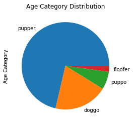

```python
master_df.age.value_counts().plot(
    backend="matplotlib",
    kind="pie",
    ylabel="Age Category",
    title="Age Category Distribution",
);
```

## 6. How strong is the correlation between ratings and retweet counts/favorite counts?

```python
fig = master_df.plot(x="rating", y="retweet_count", kind="scatter")
fig.update_traces(hovertemplate="Rating: %{x}<br />Retweet count: %{y} <extra></extra>")
fig.update_layout(xaxis_title="Rating", yaxis_title="Retweet Count", hoverlabel=dict(bgcolor="white"),
    showlegend=False, title="Correlation between ratings and retweet counts", title_x=0.5)
```

[interactive chart not shown]

```python
fig = master_df.plot(x="rating", y="favorite_count", kind="scatter")
fig.update_traces(hovertemplate="Rating: %{x}<br />Favorite count: %{y} <extra></extra>")

fig.update_layout(xaxis_title="Rating", yaxis_title="Favorite Count", hoverlabel=dict(bgcolor="white"),
    showlegend=False, title="Correlation between ratings and favorite counts", title_x=0.5)
```

[interactive chart not shown]

## 7. What are the 10 most popular dog names?

```python
fig = master_df.name.value_counts()[:10].plot.barh()
fig.update_traces(hovertemplate="Count: %{x}<extra></extra>")
fig.update_layout(xaxis_title="Count", yaxis_title="Names", hoverlabel=dict(bgcolor="white"),
    showlegend=False, title="The 10 most popular dog names", title_x=0.5)
```

[interactive chart not shown]

## 8. What are the 5 highest rated dog breeds?

```python
highest_rated_breeds = (master_df.groupby("dog_breed")["rating"].mean().sort_values(ascending=False)[:5])
fig = highest_rated_breeds.plot(kind="bar")
fig.update_traces(hovertemplate="Mean rating: %{y}<extra></extra>")
fig.update_layout(xaxis_title="Dog Breed", yaxis_title="Mean Rating", hoverlabel=dict(bgcolor="white"),
    showlegend=False, title="The 5 highest rated dog breeds", title_x=0.5)
```

[interactive chart not shown]